# Assignment #2

You will need **PLINK2** installed and available in your PATH. Please follow the OS-specific setup guide in `SETUP.md`. The dataset for this assignment consists of the following binary PLINK files: `gwa.A2.bed`, `gwa.A2.bim`, `gwa.A2.fam` , available at the following Google Drive link: https://drive.google.com/drive/folders/1rHoy3z52Yyj985ukjjtLhfIBxchpyYtZ?usp=drive_link. Please download all three files and save them in `02_activities/data/`.

#### Question 1: Data inspection

Before you run any models, first get familiar with the dataset. You may find `data.table::fread()` in R helpful for reading `.bim` and `.fam` files.

```r
# Loading libraries
library(data.table)
library(dplyr)
library(ggplot2)
library(qqman)
```

1. Read the `.fam` file. How many samples does the dataset contain?

```r
fam_all <- fread("../data/gwa.A2.fam")
colnames(fam_all) <- c("FID", "IID", "PAT", "MAT", "SEX", "PHENOTYPE")
nrow(fam_all) #4000 samples
```

```
[1] 4000
```

2. Read the `.bim` file. How many SNPs does the dataset contain?

```r
bim_all<- fread("../data/gwa.A2.bim")
colnames(bim_all) <- c("CHR", "SNP", "CM", "BP", "A1", "A2")
length(unique(bim_all$SNP)) #306102 SNPs
```

```
[1] 306102
```

3. Make a histogram (or density plot) of the phenotype. Does it look roughly Gaussian?

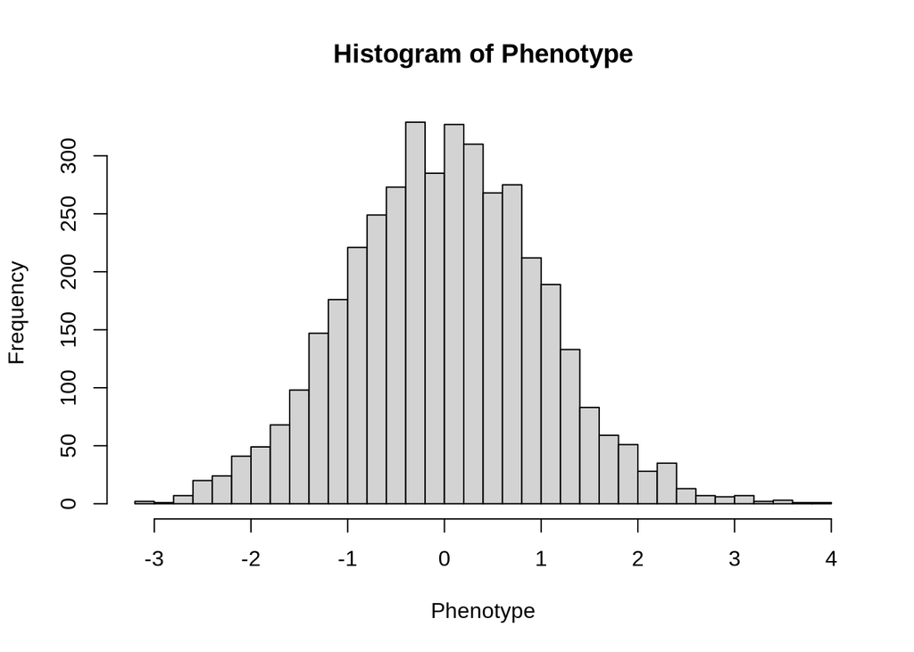

```r
hist(fam_all$PHENOTYPE, breaks=30, main="Histogram of Phenotype", xlab="Phenotype")
```

```r
# The histogram shows a normal/gaussian distribution (bell-shaped distribution).
```

#### Question 2: Quality control (QC)

Now we will perform QC using PLINK2 for the genotype files in `gwa.A2`.

1. Using PLINK2 from the command line (bash), perform basic QC with the following filters: MAF ≥ 0.05, SNP missingness (`--geno`) ≤ 0.01, individual missingness (`--mind`) ≤ 0.10, and HWE p-value ≥ 0.00005, and output the QC’ed dataset as `gwa.qc.A2`.

```bash
plink2 --bfile ../data/gwa.A2 \
       --maf 0.05 \
       --geno 0.01 \
       --mind 0.10 \
       --hwe 0.00005 \
       --make-bed \
       --out ../data/gwa.qc.A2
```

#### Question 3: Relatedness

In this question, you will use **PLINK2’s built-in KING-robust kinship** (`--king-cutoff`) detect and remove related individuals.

1. Perform LD pruning on `gwa.qc.A2` using PLINK2 with the following parameters: `--indep-pairwise 500 50 0.05`, and then generate a new dataset containing only the pruned SNPs.

```bash
plink2 --bfile ../data/gwa.qc.A2 \
       --indep-pairwise 500 50 0.05 \
       --out ../data/gwa.qc.A2.prune
```

2. Use PLINK2 on the LD-pruned dataset to identify a set of unrelated individuals up to (approximately) 2nd-degree relatives (use a kinship cutoff of 0.0884).

```bash
plink2 --bfile ../data/gwa.qc.A2 \
       --extract ../data/gwa.qc.A2.prune.prune.in \
       --king-cutoff 0.0884 \
       --out ../data/gwa.qc.A2.king

tail -n +2 ../data/gwa.qc.A2.king.king.cutoff.in.id | wc -l #4000 unrelated
tail -n +2 ../data/gwa.qc.A2.king.king.cutoff.out.id | wc -l #0 related
```

3. Using the unrelated individual list from part (ii), create a dataset containing only unrelated individuals and name it `gwa.qc_unrelated.A2`.

```bash
plink2 --bfile ../data/gwa.qc.A2 \
       --keep ../data/gwa.qc.A2.king.king.cutoff.in.id \
       --make-bed \
       --out ../data/gwa.qc_unrelated.A2
```

#### Question 4: principal component analysis (PCA)

1. Using PLINK2, perform PCA on the unrelated, LD-pruned dataset to obtain principal components.

   (Hint: Refer to the PCA section in the GWAS Tutorial II. You should use a `*.prune.in` file to select a set of independent SNPs before performing PCA.)

```bash
plink2 --bfile ../data/gwa.qc_unrelated.A2 \
       --extract ../data/gwa.qc.A2.prune.prune.in \
       --make-bed \
       --out ../data/gwa.qc_unrelated_pruned.A2

plink2 --bfile ../data/gwa.qc_unrelated_pruned.A2 \
       --pca 20 \
       --threads 8 \
       --out ../data/gwa_qc_unrelated_pruned_pca.A2
```

```bash
head -n 5 ../data/gwa_qc_unrelated_pruned_pca.A2.eigenvec
```

```
#FID    IID PC1 PC2 PC3 PC4 PC5 PC6 PC7 PC8 PC9 PC10    PC11    PC12    PC13    PC14    PC15    PC16    PC17    PC18    PC19    PC20
0   A2001   0.0145843   -0.00733461 0.0136508   -0.0250369  -0.00869184 0.00617691  6.98076e-05 0.00308451  -0.0214141  0.0183368   -0.0177254  -0.00928609 -0.0255812  -0.0208478  -0.00517104 -0.00577622 -0.0242952  0.0376308   -0.00358238 0.00752625
1   A2002   -0.00150493 0.0187157   -0.0146642  0.0201493   0.0111734   -0.030082   0.00556865  0.000806422 0.0117109   -0.013931   0.0204507   -0.000266312    0.00907452  0.0108504   0.0141088   -0.0110702  -0.00973326 -0.000971085    -0.00851025 0.00506885
2   A2003   -0.0115834  -0.00183746 -0.00736085 -0.0286359  0.00079377  -0.00540241 0.00615939  0.0109209   -0.0178088  -0.0362473  0.0185428   -0.0290534  -0.0192927  -0.00633526 0.0144719   -0.0188648  0.0117552   -0.0145622  0.0147636   -0.00998669
3   A2004   0.00989554  0.0194027   0.00266851  -0.000117053    -0.0262015  0.0156717   -0.019175   -0.00136439 0.0200712   0.0391939   0.00923002  -0.0240591  0.00562301  -0.0167357  -0.0182514  0.00501032  -0.00755118 0.00536281  -0.00206417 0.0194767
```

#### Question 5: GWAS analyses

We now test for association between each SNP and the continuous phenotype, adjusting for population structure using the top 3 PCs.

Assume that:

- You will run GWAS on the unrelated, QC’ed dataset `gwa.qc_unrelated.A2`.
- You have a covariate file (e.g., the `*.eigenvec` output from the PCA analysis) containing PC1–PC3 for each individual.
1. Using PLINK2, run a linear regression GWAS using `gwa.qc_unrelated.A2` as the input dataset. Adjust for PCs 1–3 as covariates.

```bash
# Adding header to the .fam file and saving for phenotype call
awk '{print $1, $2, $6}' ../data/gwa.qc_unrelated.A2.fam > ../data/gwa_unrelated.A2.phen
sed -i '1iFID IID PHENOTYPE' ../data/gwa_unrelated.A2.phen

plink2 --bfile ../data/gwa.qc_unrelated.A2 \
       --covar ../data/gwa_qc_unrelated_pruned_pca.A2.eigenvec \
       --covar-name PC1,PC2,PC3 \
       --pheno ../data/gwa_unrelated.A2.phen \
       --pheno-name PHENOTYPE \
       --linear \
       --threads 1 \
       --out ../data/gwa_qc_gwas.A2
```

2. Create a Manhattan plot of the GWAS results.

```r
dim(assoc <- data.table::fread("../data/gwa_qc_gwas.A2.PHENOTYPE.glm.linear"))
```

```
[1] 404332     16
```

```r
head(assoc)
```

```
   #CHROM     POS        ID    REF    ALT PROVISIONAL_REF?     A1 OMITTED
    <int>   <int>    <char> <char> <char>           <char> <char>  <char>
1:      1 1011278 rs3737728      G      A                Y      A       G
2:      1 1011278 rs3737728      G      A                Y      A       G
3:      1 1011278 rs3737728      G      A                Y      A       G
4:      1 1011278 rs3737728      G      A                Y      A       G
5:      1 1109721 rs1320565      C      T                Y      T       C
6:      1 1109721 rs1320565      C      T                Y      T       C
     A1_FREQ   TEST OBS_CT       BETA        SE    T_STAT        P ERRCODE
       <num> <char>  <int>      <num>     <num>     <num>    <num>  <char>
1: 0.3386490    ADD   3982  0.0182086 0.0240795  0.756187 0.449582       .
2: 0.3386490    PC1   3982 -0.3779240 1.0015500 -0.377340 0.705941       .
3: 0.3386490    PC2   3982  0.9818050 1.0015100  0.980326 0.326985       .
4: 0.3386490    PC3   3982  0.4832040 1.0015300  0.482467 0.629501       .
5: 0.0788481    ADD   3976 -0.0153297 0.0420641 -0.364436 0.715552       .
6: 0.0788481    PC1   3976 -0.4762890 1.0037500 -0.474511 0.635162       .
```

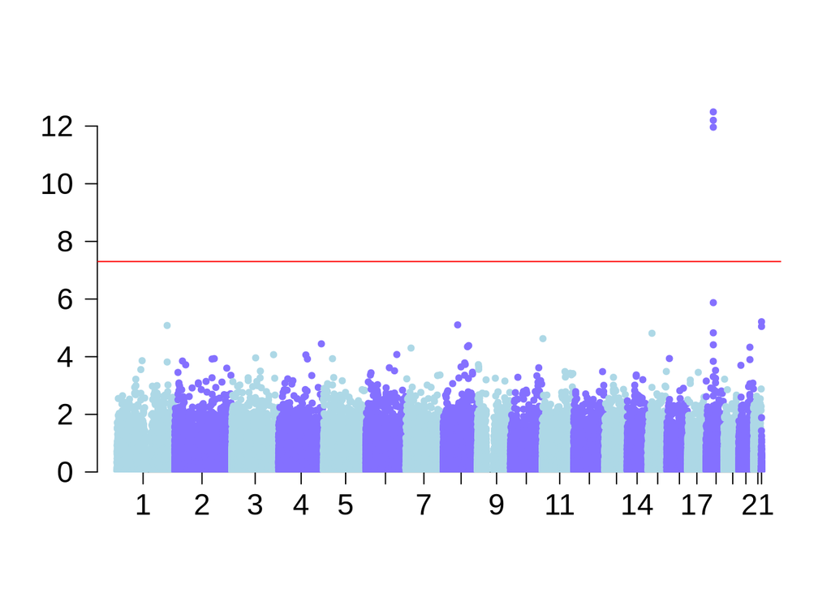

```r
# Keep only the additive test (one row per SNP)
assoc_add <- assoc[TEST == "ADD"]

# qqman expects columns named CHR, BP, SNP, and P
setnames(assoc_add, c("#CHROM","POS","ID"), c("CHR","BP","SNP"))

# Manhattan plot
manhattan(assoc_add,
          chr = "CHR",
          bp  = "BP",
          snp = "SNP",
          p   = "P",
          xlab = "",
          ylab = "",
          suggestiveline = FALSE,
          cex.axis = 1.5,
          col = c("lightblue", "lightslateblue"))
```

3. Create a QQ plot of the GWAS p-values.

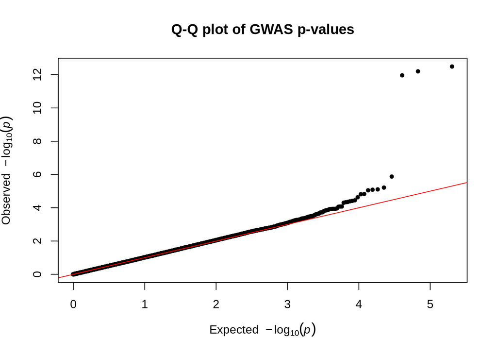

```r
qq(assoc_add$P, main = "Q-Q plot of GWAS p-values")
```

### Criteria

| Criteria | Complete | Incomplete |
| --- | --- | --- |
| **Data inspection** | Correct sample and SNP counts; phenotype plot with a brief comment on Gaussianity. | Counts or phenotype description/plot missing or incorrect. |
| **QC & LD pruning** | Correct PLINK2 QC command and thresholds. | QC/pruning commands, thresholds, or output datasets missing or incorrect. |
| **Relatedness & PCA** | Correct use of PLINK2 command to obtain unrelated samples and PCA run on pruned SNPs. | Relatedness step, unrelated dataset, or PCA analysis missing or incorrect. |
| **GWAS & visualisation** | Linear regression GWAS with PCs as covariates; Manhattan and QQ plots produced. | GWAS command, or Manhattan/QQ plots missing or clearly incorrect. |

### Submission Information

🚨 **Please review our [Assignment Submission Guide](https://github.com/UofT-DSI/onboarding/blob/main/onboarding_documents/submissions.md)** 🚨 for detailed instructions on how to format, branch, and submit your work. Following these guidelines is crucial for your submissions to be evaluated correctly.

#### Submission Parameters

- Submission Due Date: 11:59 PM – 01/04/2026
- The branch name for your repo should be: `assignment-2`
- What to submit for this assignment:
  - Populate this Quarto document (`assignment_2.qmd`).
  - Render the document with Quarto: `quarto render assignment_2.qmd`.
  - Submit both `assignment_2.qmd` and the rendered HTML file `assignment_2.html` in your pull request.
- What the pull request link should look like for this assignment: `https://github.com/<your_github_username>/gen_data/pull/<pr_id>`
  - Open a private window in your browser. Copy and paste the link to your pull request into the address bar. Make sure you can see your pull request properly. This helps the technical facilitator and learning support team review your submission easily.

Checklist:

- Create a branch called `assignment-2`.
- Ensure that your repository is public.
- Review [the PR description guidelines](https://github.com/UofT-DSI/onboarding/blob/main/onboarding_documents/submissions.md#guidelines-for-pull-request-descriptions) and adhere to them.
- Verify that your link is accessible in a private browser window.
- Confirm that both `assignment_2.qmd` and `assignment_2.html` are included in the pull request.